# xwMOOC 데이터 과학

지진해일 대피소 - crosstalk

xwMOOC

2018-01-17

## 1. 지진해일 대피소

동해안을 끼고 있는 강원도와 경상도 주민들에게 일본에서 겪고 있는 지진해일은 남의 일이 아닐 수 있다. 공공데이터를 통해 [지진해일 긴급대피소(2017.10.25.)](https://www.data.go.kr/dataset/3058512/fileData.do) 정보를 제공하고 있다.

## 2. 지진해일 대피소 시각화

공공데이터를 “EUC-KR”, “CP-949”, “UTF-8”등 다양한 방식으로 인코딩하여 제공하는지 이유는 알 수 없지만, IT강국이라 이러한 사실은 이해하고 넘어가자. 데이터를 불러왔다면 [`crosstalk`](https://rstudio.github.io/crosstalk/using.html)를 활용하여 시도명을 기준으로 지진해일 대피소에 대한 전반적인 상황을 살펴보자.

강원도, 경상북도, 울산광역시, 부산광역시 4개 광역시도에 걸쳐 지진해일 대피소가 존재하기 때문에 **시도** 드롭박스를 활용하여 지진대피소 위치를 파악하면 도움이 될 수 있다.

```r
# 0. 환경설정 -----
library(tidyverse)
library(leaflet)
library(crosstalk)
library(DT)

# 1. 데이터 가져오기 -----
# guess_encoding("data/지진해일대피소_20171025(1).csv")
shelter_df <- read.csv("data/지진해일대피소_20171025(1).csv", encoding = "EUC-KR", stringsAsFactor = FALSE) %>%
  tbl_df

shelter_df <- shelter_df %>%
  rename(longitude=경도, latitude=위도)


# 2. 데이터 정제 ------
shelter_sd <- SharedData$new(shelter_df)

filter_select("시도명", "시도", shelter_sd, ~시도명)
```

시도

```r
bscols(
  leaflet(data = shelter_sd) %>%
    addProviderTiles(providers$OpenStreetMap) %>%
    addMarkers(),

  datatable(shelter_sd,
            options=list(columnDefs = list(list(visible=FALSE,targets=c(1,3,5,6,7,8,14,15)))))
)
```

[interactive chart not shown]

|  | 일련번호 | 시도명 | 시군구명 | 대피지구명 | 대피장소명 | 주소 | longitude | latitude | 수용가능인원수.명. | 해변으로부터거리.M. | 대피소.분류명 | 내진적용여부 | 해발높이 | 관리기관 | 관리기관연락처 |
| --- | --- | --- | --- | --- | --- | --- | --- | --- | --- | --- | --- | --- | --- | --- | --- |
| 1 | 1 | 강원도 | 강릉시 | 강문 | 강릉고등학교 | 강원도 강릉시강릉대로587번길 68 | 128.91686 | 37.787813 | 8600 | 550 | 공공건축물 | 2등급 | 6 | 42150 | 033-640-5527 |
| 2 | 2 | 강원도 | 강릉시 | 강문 | 강릉교회 | 강원도 강릉시해안로 333 | 128.916247 | 37.793313 | 3600 | 100 | 민간건축물 | 2등급 | 6 | 42150 | 033-640-5526 |
| 3 | 3 | 강원도 | 강릉시 | 경포 | 경포산장콘도 | 강원도 강릉시안현동 50-2 | 128.900098 | 37.809654 | 800 | 300 | 민간건축물 | 1등급 | 22.9 | 42150 | 033-640-5523 |
| 4 | 5 | 강원도 | 강릉시 | 경포 | 현대아파트 앞 야산 | 강원도 강릉시저동 산10 | 128.899588 | 37.801328 | 1000 | 800 | 공터 | - | 10 | 42150 | 033-640-5525 |
| 5 | 6 | 강원도 | 강릉시 | 남항진 | 세인트컨벤션웨딩홀 | 강원도 강릉시공항길127번길 5-3 | 128.949709 | 37.765126 | 1000 | 250 | 민간건축물 | 2등급 | 12 | 42150 | 033-640-5528 |
| 6 | 7 | 강원도 | 강릉시 | 동덕 | 강릉원주대학 해양생물연구교육센터 | 강원도 강릉시사천면 해안로 1166 | 128.862171 | 37.850557 | 5900 | 150 | 민간건축물 | 1등급 | 7 | 42150 | 033-640-5520 |
| 7 | 8 | 강원도 | 강릉시 | 사천뒷불 | 장구바위 야산 | 강원도 강릉시사천면 사천진리 266-25 | 128.875957 | 37.840727 | 300 | 420 | 공터 | - | 10 | 42150 | 033-640-5521 |
| 8 | 9 | 강원도 | 강릉시 | 사천뒷불 | 강릉성결교회 부설 진리수양관 | 강원도 강릉시사천면 사천진리 산72-1 | 128.868683 | 37.841737 | 280 | 1100 | 민간건축물 | 1등급 | 10 | 42150 | 033-640-5522 |
| 9 | 10 | 강원도 | 강릉시 | 심곡 | 곰두리연수원 | 강원도 강릉시강동면 심곡리 90-1 | 129.050392 | 37.667539 | 150 | 350 | 민간건축물 | 2등급 | 61.2 | 42150 | 033-640-5530 |
| 10 | 11 | 강원도 | 강릉시 | 강릉항 | 송정해변 신도브래뉴아파트 | 강원도 강릉시견소동 289 | 128.937913 | 37.775796 | 3500 | 350 | 민간건축물 | 1등급 | 5.5 | 42150 | 033-640-5528 |

[output cut: 613 more lines]

## 3. 지진해일 대피소 데이터 오류

지진해일 대피소 데이터를 시각화하면서 강원도임에 불구하고 부산광역시 기장군에 속해 있는 지진 대피소가 있는 것이 확인되어 이는 공공데이터의 원천 데이터가 잘못된 것이 아닌가 판단이 든다.

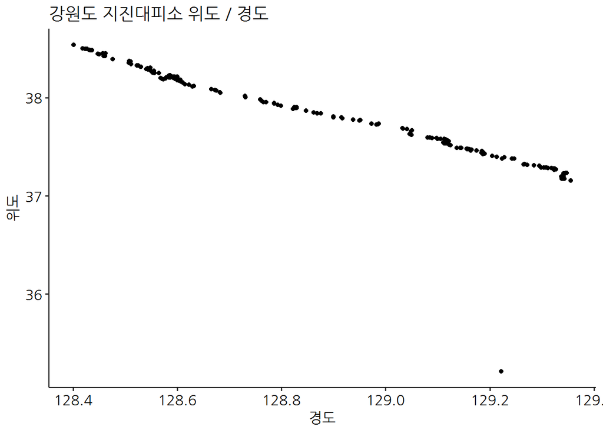

```r
# 3. 지진대피소 데이터 오류 ------
library(ggpubr)
library(extrafont)
loadfonts()

shelter_df %>%
  filter(시도명 == "강원도") %>%
   ggplot(aes(longitude, latitude)) +
    geom_point() +
    theme_pubr(base_family = "NanumGothic") +
    labs(x="경도", y="위도", title="강원도 지진대피소 위도 / 경도")
```

```r
shelter_df %>%
  filter(시도명 == "강원도") %>%
  filter(latitude < 36) %>%
  datatable()
```

|  | 일련번호 | 시도명 | 시군구명 | 대피지구명 | 대피장소명 | 주소 | longitude | latitude | 수용가능인원수.명. | 해변으로부터거리.M. | 대피소.분류명 | 내진적용여부 | 해발높이 | 관리기관 | 관리기관연락처 |
| --- | --- | --- | --- | --- | --- | --- | --- | --- | --- | --- | --- | --- | --- | --- | --- |
| 1 | 145 | 강원도 | 속초시 | 동명지구 | 속초감리교회 | 속초시 동명동 338 | 129.221761 | 35.21253 | 1500 | 450 | 공터 | - | 39 | 42210 | 033-639-2685 |

### 3.1. 공공데이터 오류 수정 방법

공공데이터의 오류가 발생했을 경우, 공공데이터 포털의 오류가 있는 데이터가 위치한 곳([지진해일 긴급대피소 현황](https://www.data.go.kr/dataset/3058512/fileData.do))으로 가서 **오류신고** 버튼을 클릭하여 신고한다.

[figure not shown]